# Gene Set Analysis (GSEA)

4/3/23

### Load data and libraries

```r
##################
# LOAD LIBRARIES #
##################
library(tidyverse)
library(Seurat)
library(SeuratObject)
library(tidyseurat)
library(cowplot)
library(ggrepel)
library(ggridges)
library(scales)
library(niceRplots)
library(fgsea)
library(openxlsx)

source("../bin/plotting_functions.R")
source("../../broliden_5325/code/enrichment_function.R")

#########
# PATHS #
#########
input_dir <- "../results/06_DGE_condition_st_data/"
result_dir <- "../results/07_GSEA_st_data/"
if( isFALSE(dir.exists(result_dir)) ) { dir.create(result_dir,recursive = TRUE) }

GO_path <- "../../broliden_5325/resources/KEGG_GO_database/c5.bp.v6.2.symbols.gmt.txt"
KEGG_path <- "../../broliden_5325/resources/KEGG_GO_database/c2.cp.kegg.v6.2.symbols.gmt.txt"

#############
# LOAD DATA #
#############
# DEGs_table <- read_csv(paste0(input_dir,"subset_100/DGEs_condition_wilcox_epi_100.csv")) %>% filter(groups == "DMPA")
DEGs_table <- read_csv(paste0(input_dir,"DGEs_condition_wilcox.csv"))
DATA <- readRDS(paste0("../results/04_deconvolution_st_data/","seuratObj_deconvolution_scdc.RDS"))

GO_database <- fgsea::gmtPathways(GO_path)
KEGG_database <- fgsea::gmtPathways(KEGG_path)
```

```r
ord1 <- c("Sup_1","Sup_2","Basal_2","Basal_1","0","1","2","3","4","8","10")
ord2 <- c("6","9","7","5","0","1","2","3","4","8","10")

DEGs_table <- DEGs_table %>%
  mutate(subgroup = factor(.$subgroup, levels = ord2)) %>%
  mutate(layers = factor(.$layers, levels = ord1)) %>%
  dplyr::rename(Clusters="layers")
```

```r
####################
# CREATE GENE RANK #
####################
# log.pct.diff , p_val_adj
DEGs_list <- DEGs_table %>%
  group_split(., subgroup) %>%
  set_names(., sort(unique(DEGs_table$Clusters)))

get_gene_rank.fun <- function(DEGs_list, stat = "avg_log2FC"){
  stat <- sym(stat)
  gene_rank_df <- DEGs_list %>%
    map(., ~.x %>%
      select(gene, avg_log2FC) %>%
        mutate(.x, "logFC*p-val" = sign(avg_log2FC) * -log10(p_val))  %>%
        mutate(.x, stat_ord = !!(stat)) %>%
        mutate(.x, rank = rank(stat_ord))
        #mutate(.x, statsAdj = sign(stat_ord) * (abs(stat_ord) ^ 1) ) %>%
        #mutate(.x, statsAdj = statsAdj / max(abs(statsAdj))) %>%
  ) %>% map(., ~arrange(.x, stat_ord))
}
gene_rank_df <- get_gene_rank.fun(DEGs_list, "avg_log2FC")
#gene_rank_df <- get_gene_rank.fun(DEGs_list, "logFC*p-val")

gene_rank_list <- gene_rank_df %>%
  map(., ~pull(.x, stat_ord)) %>%
  map2(., DEGs_list, ~set_names(.x, pull(.y, "gene")))
```

Here is a documentation for GSEA, pointing to Enrichment Scores in particular: https://www.gsea-msigdb.org/gsea/doc/GSEAUserGuideTEXT.htm#*Enrichment_Score*(ES)

And here is one of the clearest and most thorough explanations I’ve found: https://www.pathwaycommons.org/guide/primers/data_analysis/gsea/

Answering your specific questions:

Larger magnitudes are “better” The sign on the score simply indicates when end of your ranked gene list is enriched. You provide the rank list of genes, so the biiological interpretation is up to you. If, for example, you provide a gene list ranked by a combination of fold change and p-value (e.g., sign(FC) * log10(pvalue)), then the positive scores are associated with upregulated genes and negative scores are associated with downregulated genes. Caution: some tools reverse this, so manually check a few to see which convention they are using. ES values range from -1 to 1. Normalized ES values will go a bit beyond these bounds. If you are seeing ES values > 1, then I would suspect something is wrong.

Additional comment: You probably want to look at NES (Normalized ES) if that is provided by the tool you are using. The first two points above apply just the same.

```r
# http://www.baderlab.org/ChangjiangXu/GSEA
# Create a gene rank based on the parameter chosen in the previous chunck
#####################
# RUN GESA ANALYSIS #
#####################
fgseaRes_GO <- gene_rank_list %>%
  map(., ~fgsea(pathways=GO_database, stats=.x)) %>%
  map(., ~as_tibble(.x)) %>%
  map(., ~arrange(.x, pval))

#fgseaRes_KEGG <- NULL
#fgseaRes_GO <- NULL
fgseaRes_KEGG <- gene_rank_list %>%
  map(., ~fgsea(pathways=KEGG_database, stats=.x)) %>%
  map(., ~as_tibble(.x)) %>%
  map(., ~arrange(.x, pval))

fgseaRes <- append(fgseaRes_GO, fgseaRes_KEGG)

# Show in a nice table:
# fgseaResTidy <- fgseaRes$`8` %>%
#   top_n(15, abs(NES)) %>%
#   dplyr::select(-leadingEdge, -ES, -nMoreExtreme) %>%
#   arrange(padj) #%>%
#   #DT::datatable()
```

### save GESA object

```r
saveRDS(fgseaRes, paste0(result_dir,"fgseaRes_tables.RDS"))
```

```r
fgseaRes <- readRDS(paste0(result_dir,"fgseaRes_tables.RDS"))
```

```r
# gene_rank_df <- gene_rank_df[[6]]
# fgseaRes <- fgseaRes[[6]]
# top_n <- 20
db <- c(rep("GO", length(fgseaRes)/2),rep("KEGG", length(fgseaRes)/2))
GSEA_table.fun <- function(fgseaRes, gene_rank_df, top_n, Cluster, n = 40){
  f <- fgseaRes  %>% # fgseaRes[["Basal_2"]]
    mutate(Direction = ifelse(ES > 0, "UP", "DOWN")) %>%
    group_by(Direction) %>%
    top_n(-pval, n = top_n) %>%
    ungroup() %>%
    #filter(padj < 0.05) %>%
    mutate(overlap = map_dbl(leadingEdge, ~length(.x)), .after = "size") %>%
    unnest(leadingEdge) %>%
    left_join(., select(gene_rank_df, gene, avg_log2FC), by=c("leadingEdge"="gene")) %>% # gene_rank_df$Basal_2
    mutate(., dir = ifelse(.$avg_log2FC < 0, "down", "up")) %>%
    group_by(pathway) %>%
    mutate(min_logFC = min(avg_log2FC)) %>%
    mutate(max_logFC = max(avg_log2FC)) %>%
    add_count(., dir) %>%
    ungroup() %>%
    select(pathway, overlap, dir, n, min_logFC, max_logFC) %>%
    unique() %>% #filter(pathway == "GO_PEPTIDE_CROSS_LINKING")
    pivot_wider(.,  names_from = dir, values_from = n)

  f_ <- fgseaRes %>% # fgseaRes[["Basal_2"]]
    left_join(., f, by="pathway") %>%
    mutate(dir = ifelse(is.na(.$down) & is.na(.$up), NA,
                        ifelse(is.na(.$up), "down",
                          ifelse(is.na(.$down) | .$down < .$up, "up", "down")))) %>%
    mutate(Direction = ifelse(ES > 0, "UP", "DOWN")) %>%
    select(-leadingEdge, leadingEdge)
  return(f_)
}

ridge_plots <- tibble(Clusters=factor(names(fgseaRes), levels = levels(DEGs_table$Clusters)),
                      db = db,
                      fgseaRes = fgseaRes) %>% arrange(Clusters)

epi_clus <- "Sup_0|Sup_1|Sup_2|Intrmed|Basal_2|Basal_1"
tab <- ridge_plots %>%
  mutate(tab = pmap(., ~GSEA_table.fun(fgseaRes=..3, gene_rank_df[[..1]], top_n=25, Cluster=..1))) %>%
  mutate(tab = map(tab, ~split(.x, .x$dir))) %>%
  unnest(c(tab)) %>%
  mutate(dir = names(tab)) %>%
  mutate(morf = ifelse(grepl(epi_clus, .$Clusters), "epi", "SubMuc")) %>%
  mutate(tab = set_names(.$tab, paste0(.data[["Clusters"]],"_",.data[["dir"]]))) %>%
  select(db, tab, morf) %>%
  group_by(morf, db) %>%
  summarise(tab = list(tab), .groups = "drop")

pmap(tab, ~write.xlsx(..3, keepNA=TRUE, na.string="NA", overwrite=TRUE,
                             file=paste0(result_dir,"GESA_",..1,"_",..2,".xlsx")))
```

### Split violin plots of genes in GO terms of intrest

```r
# dev.new(width=6.6929133858, height=5*3, noRStudioGD = TRUE)
######################
# GENES IN GESA TERM #
#####################
terms <- c("GO_KERATINOCYTE_DIFFERENTIATION", "GO_PEPTIDE_CROSS_LINKING", "GO_SKIN_DEVELOPMENT", "GO_B_CELL_MEDIATED_IMMUNITY")
terms.fun <- function(tab, term){
  term_genes <- tab %>%
    unnest(c(tab)) %>%
    mutate(clus = str_replace(names(.$tab), "_down|_up", "") ) %>%
    unnest(c(tab)) %>%
    filter(pathway == term & morf == "epi") %>%
    mutate(clus_all = paste(unique(.$clus), collapse = "$|^")) %>%
    arrange(desc(overlap)) %>%
    #filter(overlap == max(overlap)) %>%
    summarise(genes = unique(unlist(.$leadingEdge)), clus = .$clus[1], clus_all = .$clus_all[1]) %>%
    mutate( genes = factor(.$genes, levels = gene_rank_df[[.$clus[1]]]$gene)) %>%
    nest(data = c(genes)) %>%

  return(term_genes)
}

term_genes <- terms %>%
  map(., ~terms.fun(tab, .x)) %>% list_rbind()

################
# VIOLIN PLOTS #
################
library(patchwork)
violin_split.fun <- function(obj, gene_list, split.by, group.by, filt_pattern){
  obj <- filter(obj, grepl(filt_pattern, obj$layers))
  plots <- VlnPlot(obj, features = gene_list, adjust = 1/2, cols =  c("#88CCEE", "#CC6677"),
                   split.by = split.by, group.by = group.by,
                   pt.size = 0, combine = FALSE, split.plot = TRUE)
  plots <- map(plots, ~.x + geom_point(alpha = .3, size=.1, show.legend = F,
                                       position = position_jitterdodge(jitter.width=.5)) +
                 #scale_fill_manual(values = c("#88CCEE", "#CC6677")) +
                 #scale_color_manual(values = c("#88CCEE", "#CC6677")) +
                 theme(axis.title.x = element_blank()))
  p <- wrap_plots(plots, ncol = 10) + plot_layout(guides = "collect")
  h <- round(length(plots)/10)*4
return(tibble(plot=list(p), height = list(h), p = list(plots)))
}

plots <- term_genes %>%
  mutate(data = map(data, ~arrange(.x, genes))) %>%
  mutate(data = map(data, ~unlist(.x))) %>%
  pmap(., ~violin_split.fun(DATA, ..3, "groups", "layers", ..2)) %>%
  list_rbind() %>%
  mutate(term = terms)

pmap(plots, ~ggsave(paste0("./Figures/07/","DEGs_",..4,".png"), plot=..1, width = 40, height = ..2))
```

```
[[1]]
[1] "./Figures/07/DEGs_GO_KERATINOCYTE_DIFFERENTIATION.png"

[[2]]
[1] "./Figures/07/DEGs_GO_PEPTIDE_CROSS_LINKING.png"

[[3]]
[1] "./Figures/07/DEGs_GO_SKIN_DEVELOPMENT.png"

[[4]]
[1] "./Figures/07/DEGs_GO_B_CELL_MEDIATED_IMMUNITY.png"
```

```r
wrap_plots(plots[["p"]][[2]], ncol = 3) + plot_layout(guides = "collect")
```

[figure not shown]

```r
# dev.new(width=12, height=3, noRStudioGD = TRUE)
# width = aspect * height 4.857143
# height = width/aspect 10/4.857143
##################
# GESA RANK PLOT #
##################
db <- c(rep("GO", length(fgseaRes)/2),rep("KEGG", length(fgseaRes)/2))
plot_GseaTable.fun <- function(db, fgseaRes, gene_rank_list, n = 10, padj = 0.05){
    if(db == "GO"){database <- GO_database}else{database <- KEGG_database}

    #fgseaRes <- mutate(fgseaRes, pathway = formating_str.fun(fgseaRes$pathway))

    topPathwaysUp <- fgseaRes[fgseaRes$ES > 0 & fgseaRes$padj < padj,]
    topPathwaysDown <- fgseaRes[fgseaRes$ES < 0 & fgseaRes$padj < padj,]

    topPathwaysUp <- unlist(topPathwaysUp[head(order(topPathwaysUp$pval), n=n), "pathway"])
    topPathwaysDown <- unlist(topPathwaysDown[head(order(topPathwaysDown$pval), n=n), "pathway"])

    p <- plotGseaTable(database[c(topPathwaysUp, rev(topPathwaysDown))],
                  gene_rank_list, fgseaRes, gseaParam = 0.5, render=F)
    return(tibble(rank_plots=list(p), n_pathways = length(topPathwaysUp) +length(topPathwaysDown)))  # tibble(plots=list(plot), df=list(f))
    }

# fgseaRes <- fgseaRes %>%
#   map(., ~mutate(.x, pathway = formating_str.fun(.x$pathway)))

ridge_plots <- tibble(Clusters=names(fgseaRes),db = db,fgseaRes = fgseaRes)
plots_df <- pmap_dfr(ridge_plots,
              ~plot_GseaTable.fun(db=..2, fgseaRes=..3, n=10,
                                  gene_rank_list[[..1]]) ) %>%
  bind_cols(ridge_plots, .) %>%
  mutate(rank_plots = setNames(.[["rank_plots"]], .$Clusters)) %>%
  filter(n_pathways > 0)

if( isFALSE(dir.exists("./Figures/07/GO/")) ) { dir.create("./Figures/07/GO/",recursive = TRUE) }
if( isFALSE(dir.exists("./Figures/07/KEGG/")) ) { dir.create("./Figures/07/KEGG/",recursive = TRUE) }

pmap(plots_df, ~ggsave(paste0("./Figures/07/",..2,"/GSEA_rank_plot_", ..1,"_",..2, ".png"), #"GO_filt/",
                          plot=..4, width = 13, height = (..5*.3)+2 ))
```

```
[[1]]
[1] "./Figures/07/GO/GSEA_rank_plot_0_GO.png"

[[2]]
[1] "./Figures/07/GO/GSEA_rank_plot_1_GO.png"

[[3]]
[1] "./Figures/07/GO/GSEA_rank_plot_2_GO.png"

[[4]]
[1] "./Figures/07/GO/GSEA_rank_plot_3_GO.png"

[[5]]
[1] "./Figures/07/GO/GSEA_rank_plot_4_GO.png"

[[6]]
[1] "./Figures/07/GO/GSEA_rank_plot_8_GO.png"

[[7]]
[1] "./Figures/07/GO/GSEA_rank_plot_Basal_1_GO.png"

[[8]]
[1] "./Figures/07/GO/GSEA_rank_plot_Basal_2_GO.png"

[[9]]
[1] "./Figures/07/GO/GSEA_rank_plot_Sup_1_GO.png"

[[10]]
[1] "./Figures/07/GO/GSEA_rank_plot_Sup_2_GO.png"

[[11]]
[1] "./Figures/07/KEGG/GSEA_rank_plot_0_KEGG.png"

[[12]]
[1] "./Figures/07/KEGG/GSEA_rank_plot_1_KEGG.png"

[[13]]
[1] "./Figures/07/KEGG/GSEA_rank_plot_2_KEGG.png"

[[14]]
[1] "./Figures/07/KEGG/GSEA_rank_plot_3_KEGG.png"

[[15]]
[1] "./Figures/07/KEGG/GSEA_rank_plot_4_KEGG.png"

[[16]]
[1] "./Figures/07/KEGG/GSEA_rank_plot_8_KEGG.png"

[[17]]
[1] "./Figures/07/KEGG/GSEA_rank_plot_Sup_1_KEGG.png"

[[18]]
[1] "./Figures/07/KEGG/GSEA_rank_plot_Sup_2_KEGG.png"
```

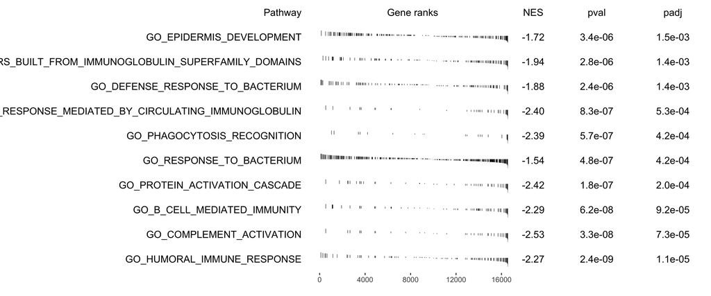

```r
grid::grid.draw(plots_df$rank_plots$Basal_2)
```